# Shiny_Project

September 11, 2017

## Introduction

**About the Data**

The Chatterjee-Price Attitude data in datasets package is used for this shiny App.

The Overall Rating and the six features (Handling of employee complaints, Does not allow special privileges, Opportunity to learn, Raises based on performance, Too critical and Advancement) on which it depends are recorded in this data.

More details about the data is available here: https://stat.ethz.ch/R-manual/R-devel/library/datasets/html/attitude.html

We try to predict the Overall rating based on a single feature viz., handling complaints by using a simple linear regression.

**About the Shiny App**

The user inputs the value for the feature : Handling of employee complaints.

The input is recorded to predict the overall rating using a simple linear regression model fit.

The output is displayed in the plot and also as a reading.

## Embedded Shiny App

[output not shown]

Shiny applications not supported in static R Markdown documents

## Snap of shiny app

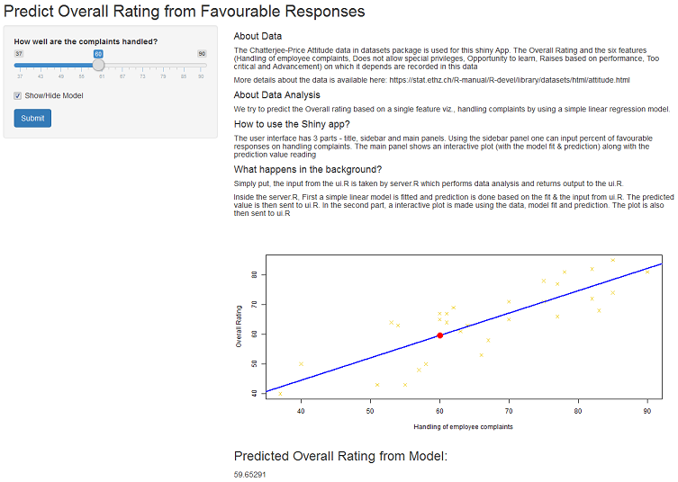